# Tea Blending Optimisation: A Comprehensive Analysis

STA5074Z Prescriptive Analytics

Tinotenda Muzambi - MZMTIN002

2025-11-16

# 1 Introduction

Blending problems are a classic challenge in operations research, arising in diverse fields such as food processing, metallurgy, and energy. In the tea industry, blending is crucial to achieve consistent product quality, balance raw material costs, and adapt to fluctuating supplies. Every cup of tea on the supermarket shelf is the result of a carefully orchestrated process. Different grades and types of tea leaves from various origins are combined to meet precise targets for taste, colour, aroma and other quality parameters, all while minimising production costs and ensuring supply constraints are not violated.

In the context of tea manufacturing, the blending optimisation problem involves selecting the optimal composition of raw teas to satisfy desired blend qualities for multiple final blends. This not only impacts the sensory profile and brand identity of each product, but also has substantial operational and economic implications. By applying advanced computational techniques, such as mathematical programming and metaheuristics, producers can automate and enhance the blending decision-making process, yielding better margins, consistent quality and greater responsiveness to market demands.

Below, we formally define the tea blending optimisation problem and systematically explore several approaches for solving it. The problem requires determining the least-cost combination of raw materials to produce final blends that meet specific quality characteristics, as formalised by Fomeni<sup>[1]</sup>.

The primary objectives are:

1. To implement and solve a cost-minimisation model using Linear Programming (LP).
2. To solve the same problem using Simulated Annealing (SA) metaheuristic and compare performance.
3. To formulate and solve a multi-objective model using Chebyshev Goal Programming.
4. To explore Genetic Algorithms (GAs) as an alternative solution approach.

# 2 Problem Formulation and Data Preparation

## 2.1 Notations and Parameters

- **Indices**:
  - $i$: Index for raw materials
  - $j$: Index for final blends
  - $k$: Index for quality characteristics
- **Parameters**:
  - $P_i$: Unit cost of raw material $i$ (£/Kg)
  - $D_j$: Weekly demand for final blend $j$ (Kgs)
  - $a_i$: Weekly availability of raw material $i$ (Kgs)
  - $g_{ik}$: Grade of characteristic $k$ in one unit of raw material $i$
  - $s_{jk}$: Required target score of characteristic $k$ in one unit of final blend $j$
- **Decision Variables**:
  - $x_{ij}$: Amount (in Kgs) of raw material $i$ to be used in final blend $j$

## 2.2 Data Source

This project uses the real-world data from Fomeni<sup>[1]</sup>, extracted from tables 2 and 3 of the paper. These data represent actual tea blending scenarios from a UK-based tea company. The data are loaded and prepared in section 3 below.

# 3 Data Implementation (Fomeni 2018)

This section implements the tea blending optimisation problem using the actual data provided in Fomeni<sup>[1]</sup>. The data consist of 60 raw materials and 10 final blends, each with 6 quality characteristics.

## 3.1 Data Loading

```
## === Data Summary ===
```

```
## Number of raw materials: 60
```

```
## Number of blends: 10
```

```
## Number of quality characteristics: 6
```

```
## Price range: £0.0120 - £0.0470 per kg
```

```
## === Raw Materials Data (Fomeni Table 2 - First 10 rows) ===
```

Raw Materials: Costs (£/kg), Availability (kg), and Quality Characteristics (First 10)

| Material_ID | Cost | Availability | C1 | C2 | C3 | C4 | C5 | C6 |
| --- | --- | --- | --- | --- | --- | --- | --- | --- |
| R1 | 0.0240 | 5,000 | 5 | 4 | 9 | 6 | 5 | 5 |
| R2 | 0.0167 | 1,000 | 5 | 3 | 9 | 4 | 5 | 1 |
| R3 | 0.0235 | 25,000 | 5 | 4 | 9 | 6 | 5 | 1 |
| R4 | 0.0170 | 1,000 | 5 | 3 | 9 | 4 | 5 | 1 |
| R5 | 0.0230 | 25,000 | 5 | 4 | 9 | 6 | 5 | 1 |
| R6 | 0.0265 | 20,000 | 7 | 4 | 9 | 6 | 7 | 1 |
| R7 | 0.0265 | 20,000 | 7 | 4 | 9 | 6 | 7 | 1 |
| R8 | 0.0294 | 1,000 | 8 | 4 | 9 | 6 | 8 | 5 |
| R9 | 0.0284 | 15,000 | 8 | 4 | 9 | 6 | 8 | 1 |
| R10 | 0.0284 | 15,000 | 8 | 4 | 9 | 6 | 8 | 1 |

```
## === Blends Data (Fomeni Table 3) ===
```

Blends: Demand (kg) and Target Quality Scores

| Blend_ID | Demand | C1 | C2 | C3 | C4 | C5 | C6 |
| --- | --- | --- | --- | --- | --- | --- | --- |
| B1 | 100,000 | 2.3 | 3.0 | 3.0 | 2.0 | 2.32 | 1 |
| B2 | 100,000 | 3.8 | 4.7 | 2.9 | 3.0 | 3.80 | 1 |
| B3 | 60,000 | 6.6 | 5.2 | 6.1 | 6.9 | 6.60 | 1 |
| B4 | 100,000 | 6.2 | 5.2 | 5.3 | 6.4 | 6.20 | 1 |
| B5 | 100,000 | 4.7 | 5.1 | 4.5 | 5.0 | 4.70 | 1 |
| B6 | 50,000 | 8.4 | 4.7 | 6.7 | 7.3 | 8.40 | 1 |
| B7 | 10,000 | 4.0 | 0.5 | 1.0 | 5.0 | 4.00 | 1 |
| B8 | 5,000 | 5.9 | 0.5 | 1.0 | 3.9 | 5.90 | 1 |
| B9 | 10,000 | 7.0 | 3.9 | 9.0 | 5.9 | 7.00 | 1 |
| B10 | 20,000 | 4.0 | 2.0 | 3.0 | 2.0 | 4.00 | 9 |

```
## === Feasibility Check ===
```

```
## Total availability: 830500 kg
```

```
## Total demand: 555000 kg
```

```
## Surplus availability: 275500 kg (49.64%)
```

## 3.2 Data Characteristics

```
## === Summary Statistics ===
```

```
## Raw Material Prices (£/kg):
```

Price Distribution Statistics

| Statistic | Value |
| --- | --- |
| Mean | £0.0217 |
| Median | £0.0195 |
| Minimum | £0.0120 |
| Maximum | £0.0470 |
| Standard Deviation | £0.0076 |

```
## Raw Material Availability:
```

Availability Distribution Statistics (kg)

| Statistic | Value_kg |
| --- | --- |
| Mean | 13842 |
| Median | 5000 |
| Minimum | 500 |
| Maximum | 80000 |
| Total | 830500 |

```
## Quality Characteristics:
```

Quality Characteristics Summary Statistics

| Characteristic | Minimum | Maximum | Mean | Median | Std_Dev |
| --- | --- | --- | --- | --- | --- |
| C1 | 2.0 | 9 | 5.500000 | 5.0 | 1.917802 |
| C2 | 0.5 | 8 | 3.333333 | 3.0 | 1.990798 |
| C3 | 1.0 | 9 | 4.316667 | 4.0 | 2.507559 |
| C4 | 2.0 | 8 | 4.500000 | 3.5 | 2.452947 |
| C5 | 2.0 | 9 | 5.500000 | 5.0 | 1.917802 |
| C6 | 1.0 | 9 | 1.933333 | 1.0 | 1.858254 |

```
## Blend Demands:
```

Blend Demand Statistics (kg)

| Statistic | Value_kg |
| --- | --- |
| Mean | 55500 |
| Median | 55000 |
| Minimum | 5000 |
| Maximum | 100000 |
| Total | 555000 |

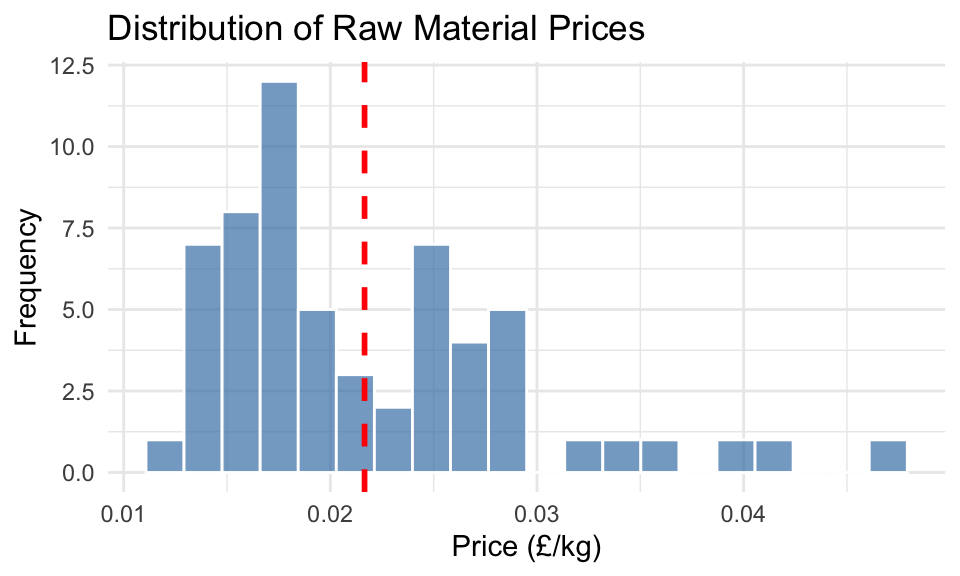

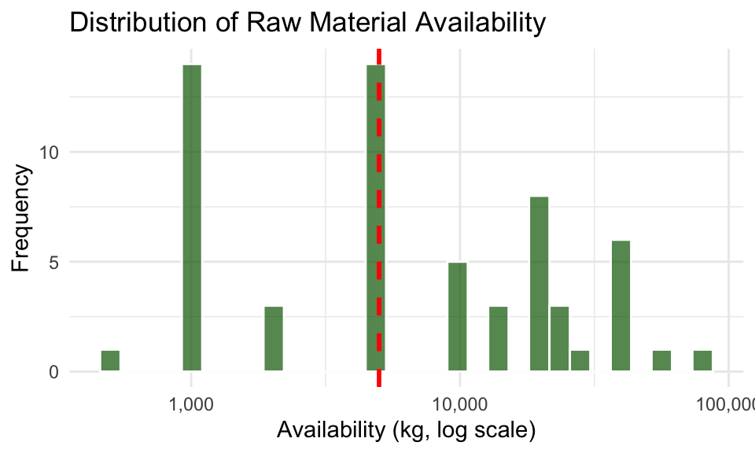

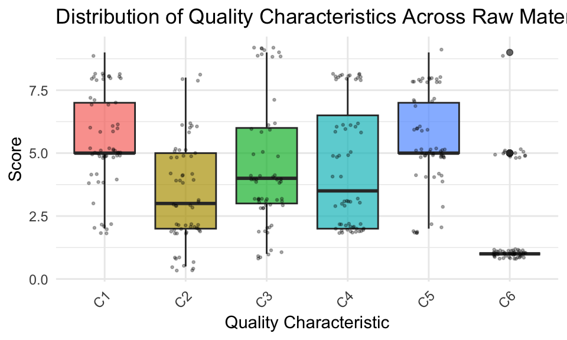

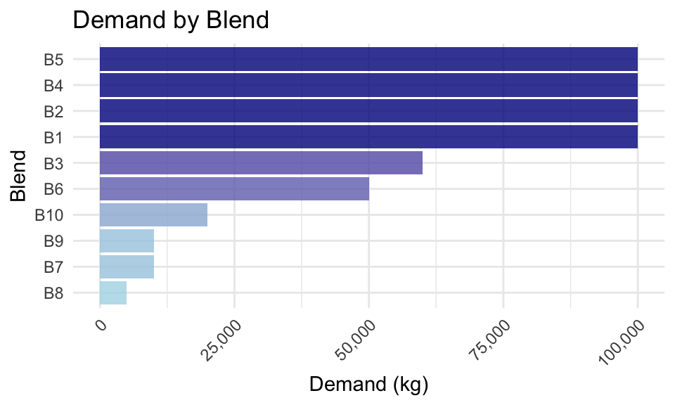

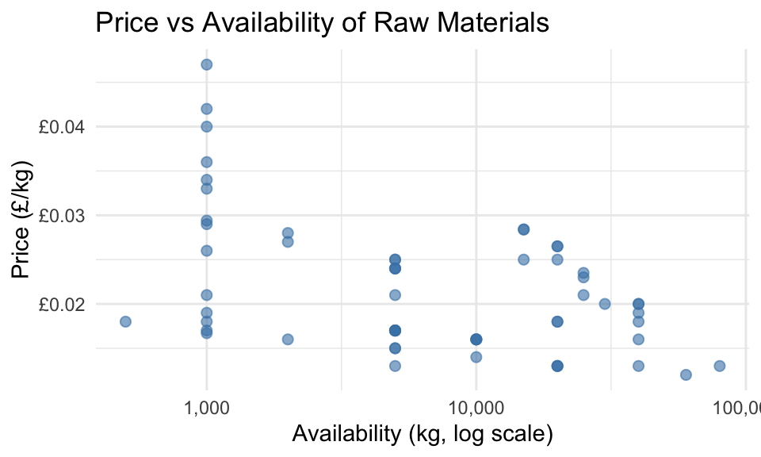

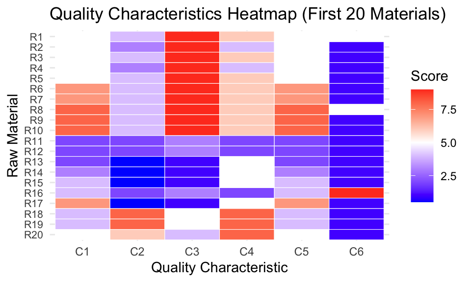

# 4 Approach 1: Cost Minimisation using Linear Programming

This section implements the cost-minimisation model using Linear Programming with parametric relaxation of the characteristic-matching constraints. This involves implementing a cost-minimisation LP model that finds the optimal combination of raw materials to produce blends meeting demand and quality constraints. This implementation uses Rglpk which provides a straightforward matrix-based formulation that is well-suited for this problem type.

## 4.1 Model Formulation

**Objective Function**: Minimise total cost
$$\min \sum_{i} \sum_{j} P_i x_{ij}$$

**Subject to Constraints**:

1. Raw Material Availability: $\sum_{j} x_{ij} \le a_i \quad \forall i$
2. Blend Demand: $\sum_{i} x_{ij} \ge D_j \quad \forall j$
3. Characteristic Score Relaxation:
   - $\sum_{i} (g_{ik} - (s_{jk} + \epsilon_{jk})) x_{ij} \le 0 \quad \forall j, k$
   - $\sum_{i} (g_{ik} - (s_{jk} - \epsilon_{jk})) x_{ij} \ge 0 \quad \forall j, k$
4. Non-negativity: $x_{ij} \ge 0 \quad \forall i, j$

## 4.2 Implementation

```
## === LP Solution Results ===
```

```
## Solver Status: 0 (0 = optimal)
```

```
## Optimal Total Cost: £9087.69
```

```
## Total material used: 555000.00 Kgs
```

```
## Total demand required: 555000.00 Kgs
```

```
## === LP Solution Summary ===
```

```
## Total materials used: 52 out of 60
```

```
## Materials with non-zero allocation: R1, R2, R3, R4, R6, R7, R8, R9, R10, R11, R12, R13, R14, R15, R16, R17, R18, R19, R20, R21, R22, R25, R26, R27, R28, R30, R31, R32, R33, R34, R35, R36, R37, R38, R40, R42, R43, R44, R45, R46, R47, R48, R49, R50, R52, R54, R55, R56, R57, R58, R59, R60
```

```
## Note: The complete recipe matrix (all 60 materials × 10 blends) is provided in Appendix 11.1.
```

```
## === Quality Deviations from Targets ===
```

Absolute deviations from target quality scores

| Blend | C1 | C2 | C3 | C4 | C5 | C6 |
| --- | --- | --- | --- | --- | --- | --- |
| B1 | 0.5000000 | 0.50000000 | 0.05429705 | 0.5000000 | 0.4800000 | 0.19873016 |
| B2 | 0.5000000 | 0.50000000 | 0.50000000 | 0.5000000 | 0.5000000 | 0.12126984 |
| B3 | 0.3736758 | 0.50000000 | 0.50000000 | 0.1152129 | 0.3736758 | 0.06666667 |
| B4 | 0.5000000 | 0.43809524 | 0.24592593 | 0.1150794 | 0.5000000 | 0.24000000 |
| B5 | 0.5000000 | 0.32182063 | 0.50000000 | 0.5000000 | 0.5000000 | 0.10000000 |
| B6 | 0.5000000 | 0.07333333 | 0.10666667 | 0.1400000 | 0.5000000 | 0.16000000 |
| B7 | 0.3977401 | 0.50000000 | 0.50000000 | 0.5000000 | 0.3977401 | 0.23728814 |
| B8 | 0.5000000 | 0.25000000 | 0.50000000 | 0.3000000 | 0.5000000 | 0.00000000 |
| B9 | 0.2333333 | 0.16666667 | 0.50000000 | 0.2333333 | 0.2333333 | 0.40000000 |
| B10 | 0.0000000 | 0.37500000 | 0.00000000 | 0.0000000 | 0.0000000 | 0.50000000 |

## 4.3 Visualisation

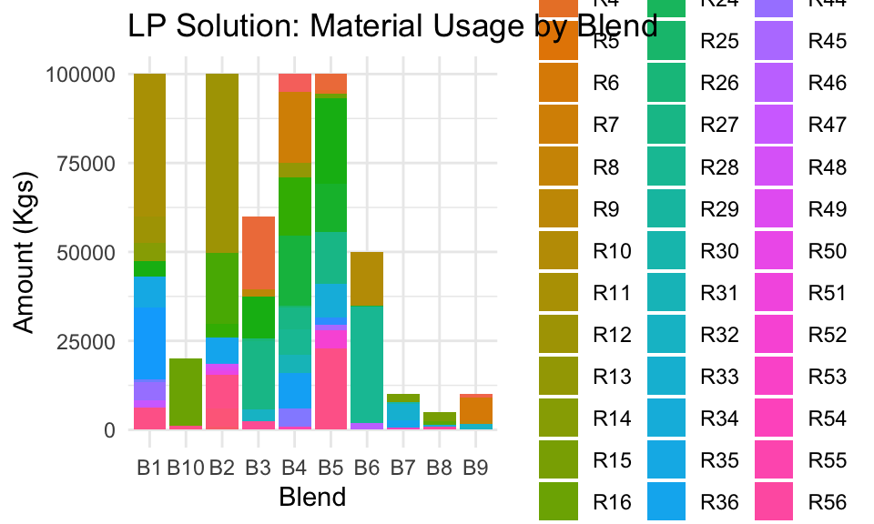

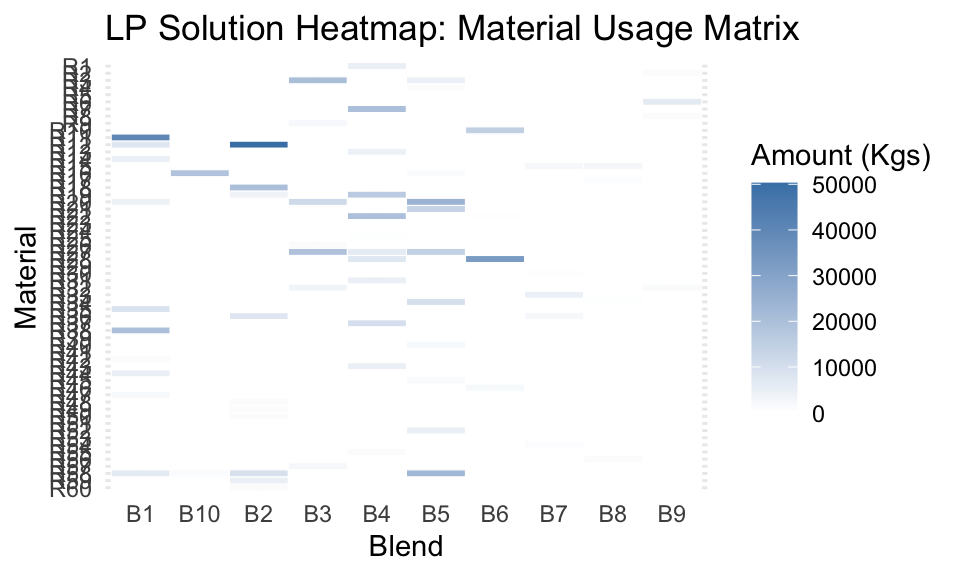

# 5 Approach 2: Cost Minimisation using Simulated Annealing

Simulated Annealing is a metaheuristic that explores the solution space probabilistically, accepting worse solutions with decreasing probability as the algorithm “cools down.”

## 5.1 Implementation

```
## Running Simulated Annealing...
```

```
## === SA Solution Results ===
```

```
## Best Total Cost: £10795.51
```

```
## Difference from LP: 18.79%
```

```
## === SA Solution Summary ===
```

```
## Total materials used: 60 out of 60
```

```
## Materials with non-zero allocation: R1, R2, R3, R4, R5, R6, R7, R8, R9, R10, R11, R12, R13, R14, R15, R16, R17, R18, R19, R20, R21, R22, R23, R24, R25, R26, R27, R28, R29, R30, R31, R32, R33, R34, R35, R36, R37, R38, R39, R40, R41, R42, R43, R44, R45, R46, R47, R48, R49, R50, R51, R52, R53, R54, …
```

```
## Note: The complete recipe matrix (all 60 materials × 10 blends) is provided in Appendix 11.2.
```

```
## === Quality Deviations from Targets ===
```

Absolute deviations from target quality scores

| Blend | C1 | C2 | C3 | C4 | C5 | C6 |
| --- | --- | --- | --- | --- | --- | --- |
| B1 | 2.8571359 | 0.62108629 | 1.5328079 | 3.1645267 | 2.8371359 | 0.4908296 |
| B2 | 1.2477335 | 1.18437375 | 1.3640062 | 1.7672207 | 1.2477335 | 0.4991178 |
| B3 | 1.1519617 | 1.21543335 | 1.4075063 | 1.5895608 | 1.1519617 | 0.2905807 |
| B4 | 0.8662446 | 1.56078069 | 0.6136058 | 1.0641442 | 0.8662446 | 0.4184949 |
| B5 | 0.4922247 | 1.08318716 | 0.3336484 | 0.1023622 | 0.4922247 | 0.3738561 |
| B6 | 3.0985450 | 0.82261570 | 1.9258952 | 1.7911687 | 3.0985450 | 0.3963816 |
| B7 | 0.5526405 | 2.61451989 | 3.0536497 | 0.4995202 | 0.5526405 | 0.2895009 |
| B8 | 1.0648341 | 3.02855262 | 3.3134596 | 1.0539680 | 1.0648341 | 0.1548552 |
| B9 | 1.6284281 | 0.07922643 | 4.1792680 | 0.3354948 | 1.6284281 | 0.3492851 |
| B10 | 1.1669845 | 1.64552835 | 1.6385125 | 3.2679182 | 1.1669845 | 7.5810173 |

## 5.2 Visualisation

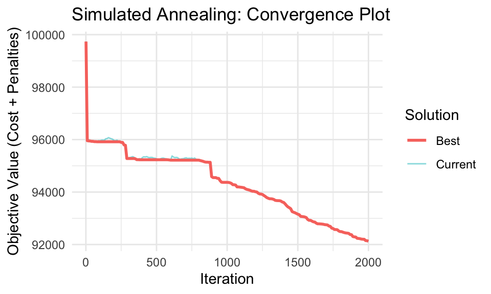

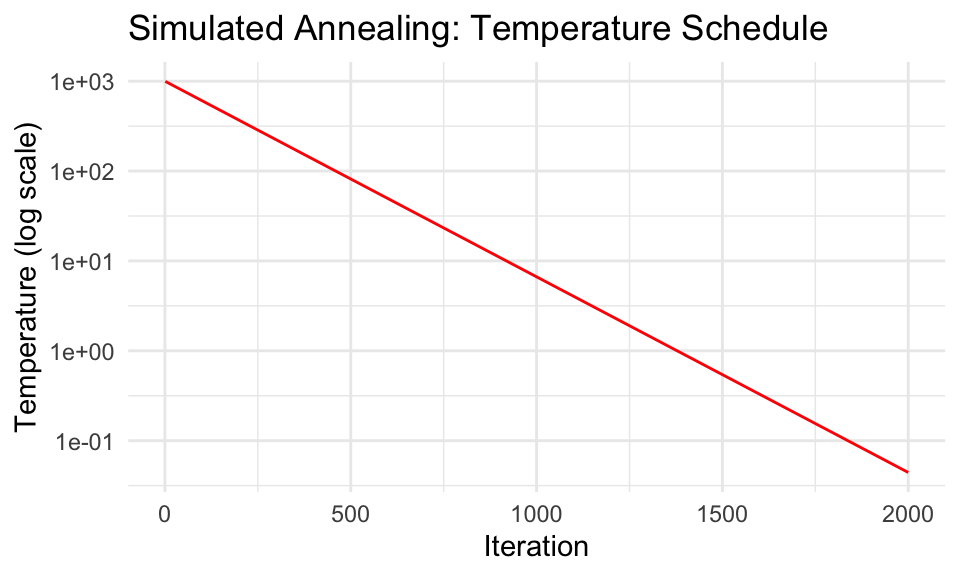

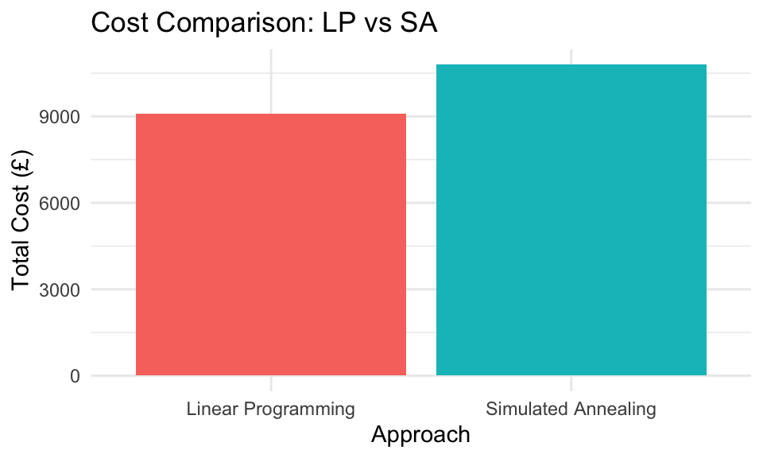

# 6 Approach 3: Multi-objective Optimisation using Chebyshev Goal Programming

Chebyshev Goal Programming minimises the worst-case deviation from multiple goals, providing a balanced solution that trades off cost for quality control.

## 6.1 Model Formulation

**Objective Function**: Minimise worst-case deviation
$$\min \max\{w_0 \cdot d_0, w_{jk} \cdot
d_{jk}\}$$

Where: - $d_0$: Deviation from cost goal - $d_{jk}$: Deviation from quality goal for blend $j$, characteristic $k$

**Constraints**: - All LP constraints - Goal constraints for cost and quality

## 6.2 Implementation

```
## Solving Chebyshev Goal Programming model...
```

```
## === Chebyshev GP Solution Results ===
```

```
## Worst-case Deviation (z): 39945.0309
```

```
## Total Cost: £10375.59
```

```
## Cost Deviation from Target: £379.13
```

```
## === Chebyshev GP Solution Summary ===
```

```
## Total materials used: 48 out of 60
```

```
## Materials with non-zero allocation: R2, R4, R5, R6, R7, R8, R9, R10, R11, R12, R13, R14, R16, R17, R18, R19, R20, R21, R22, R23, R24, R25, R27, R29, R32, R33, R35, R36, R38, R39, R40, R42, R43, R44, R45, R46, R47, R48, R49, R50, R51, R52, R54, R55, R56, R58, R59, R60
```

```
## Note: The complete recipe matrix (all 60 materials × 10 blends) is provided in Appendix 11.3.
```

```
## === Quality Deviations from Targets ===
```

Quality deviations (minimised in worst-case sense)

| Blend | C1 | C2 | C3 | C4 | C5 | C6 |
| --- | --- | --- | --- | --- | --- | --- |
| B1 | 3,324.17181172407435952 | 19,972.515 | 6,657.505 | 19,972.515 | 5,324.17181172407345002 | 0.00 |
| B2 | 19,972.51543517221944057 | 19,972.515 | 19,972.515 | 19,972.515 | 19,972.51543517226673430 | 19,972.52 |
| B3 | 0.00000000002763036 | 19,972.515 | 0.000 | 16,297.229 | 0.00000000002763036 | 0.00 |
| B4 | 19,972.51543517226309632 | 19,972.515 | 19,972.515 | 19,972.515 | 19,972.51543517226673430 | 19,972.52 |
| B5 | 19,972.51543517226673430 | 19,972.515 | 19,972.515 | 19,972.515 | 19,972.51543517226673430 | 19,972.52 |
| B6 | 19,972.51543517226309632 | 1,761.103 | 16,742.083 | 19,972.515 | 19,972.51543517226673430 | 4,000.00 |
| B7 | 0.00000000000000000 | 0.000 | 0.000 | 0.000 | 0.00000000000000000 | 0.00 |
| B8 | 0.00000000000000000 | 0.000 | 0.000 | 5,500.000 | 0.00000000000000000 | 0.00 |
| B9 | 1,250.00000000000000000 | 500.000 | 1,000.000 | 0.000 | 1,250.00000000000000000 | 0.00 |
| B10 | 0.00000000000000000 | 0.000 | 0.000 | 821.115 | 0.00000000000000000 | 6,568.92 |

## 6.3 Visualisation

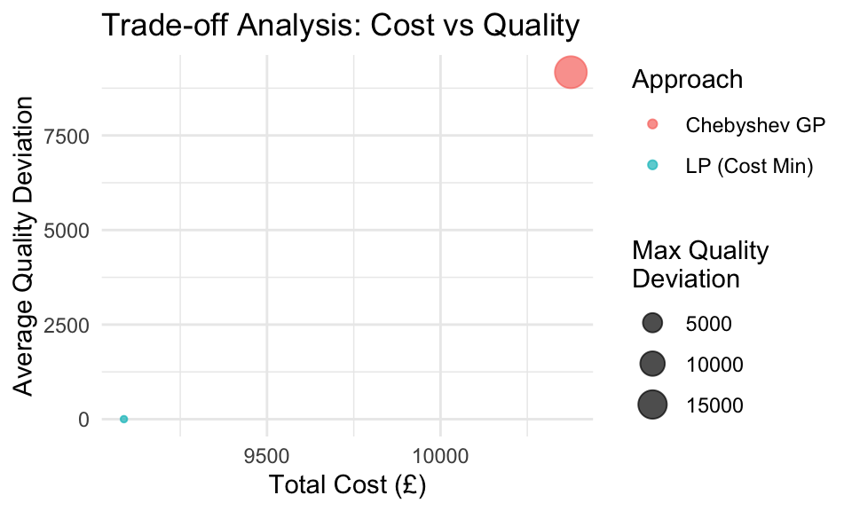

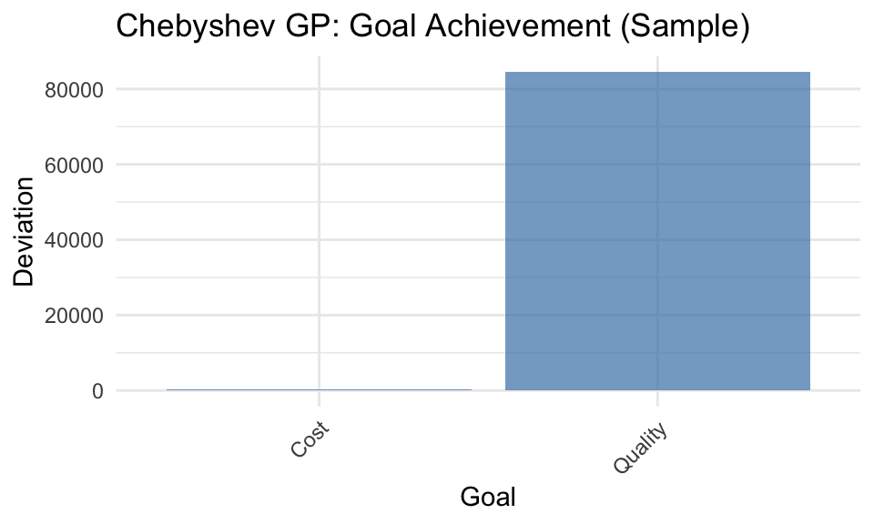

# 7 Approach 4: Genetic Algorithms

Genetic Algorithms use evolutionary principles to evolve a population of solutions toward better fitness.

## 7.1 Implementation

```
## Running Genetic Algorithm...
```

```
## === GA Solution Results ===
```

```
## Best Total Cost: £15303.76
```

```
## Average Quality Deviation: 1.4896
```

```
## === GA Solution Summary ===
```

```
## Total materials used: 60 out of 60
```

```
## Materials with non-zero allocation: R1, R2, R3, R4, R5, R6, R7, R8, R9, R10, R11, R12, R13, R14, R15, R16, R17, R18, R19, R20, R21, R22, R23, R24, R25, R26, R27, R28, R29, R30, R31, R32, R33, R34, R35, R36, R37, R38, R39, R40, R41, R42, R43, R44, R45, R46, R47, R48, R49, R50, R51, R52, R53, R54, …
```

```
## Note: The complete recipe matrix (all 60 materials × 10 blends) is provided in Appendix 11.4.
```

```
## === Quality Deviations from Targets ===
```

Absolute deviations from target quality scores

| Blend | C1 | C2 | C3 | C4 | C5 | C6 |
| --- | --- | --- | --- | --- | --- | --- |
| B1 | 2.47245775 | 0.85296693 | 1.1783179 | 3.2018719 | 2.45245775 | 0.1826701 |
| B2 | 0.94485729 | 1.09090990 | 1.6191537 | 2.1627106 | 0.94485729 | 0.3124263 |
| B3 | 1.58156774 | 1.39920921 | 1.6169238 | 1.8247903 | 1.58156774 | 0.3817459 |
| B4 | 1.34729921 | 1.42386181 | 0.9774699 | 1.1665875 | 1.34729921 | 0.2166744 |
| B5 | 0.07825342 | 1.49755347 | 0.1959262 | 0.1456025 | 0.07825342 | 0.2626848 |
| B6 | 3.12947350 | 0.88091084 | 1.8705467 | 2.0656421 | 3.12947350 | 0.3891545 |
| B7 | 0.83412122 | 3.37503639 | 3.4240546 | 0.0282352 | 0.83412122 | 0.3528171 |
| B8 | 0.92886346 | 3.20374364 | 3.4773682 | 1.1457769 | 0.92886346 | 0.3535375 |
| B9 | 1.90433481 | 0.08263197 | 4.3673788 | 0.6010388 | 1.90433481 | 0.2999490 |
| B10 | 0.68275179 | 1.82413770 | 1.3097467 | 3.0909695 | 0.68275179 | 7.7357132 |

## 7.2 Visualisation

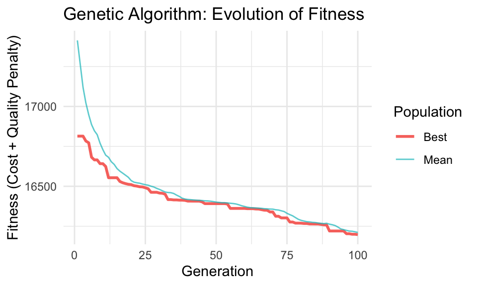

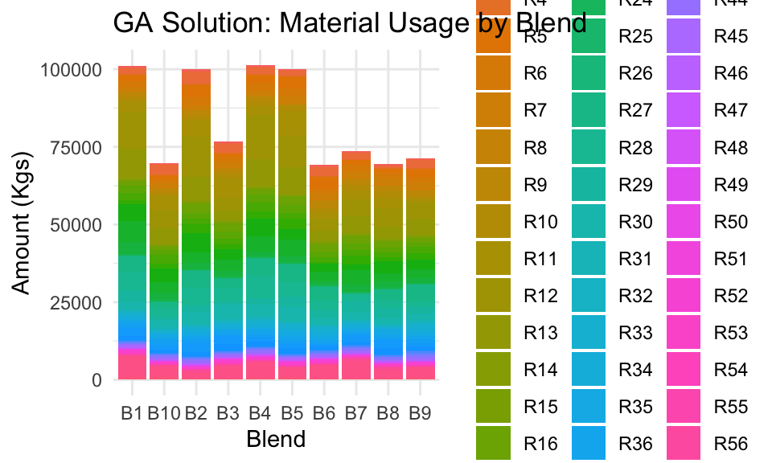

# 8 Summary of Results and Comparative Analysis

This section consolidates results from all approaches for comprehensive comparison.

## 8.1 Comparative Metrics

```
## === Comprehensive Comparison of All Approaches ===
```

Performance Metrics Comparison

| Approach | Total_Cost | Avg_Quality_Dev | Max_Quality_Dev | Cost_vs_LP_pct |
| --- | --- | --- | --- | --- |
| Linear Programming | 9,087.691 | 0.3324814 | 0.500000 | 0.00000 |
| Simulated Annealing | 10,795.508 | 1.4488489 | 7.581017 | 18.79264 |
| Chebyshev Goal Programming | 10,375.592 | 9,172.2778281 | 19,972.515435 | 14.17193 |
| Genetic Algorithm | 15,303.760 | 1.4896068 | 7.735713 | 68.40097 |

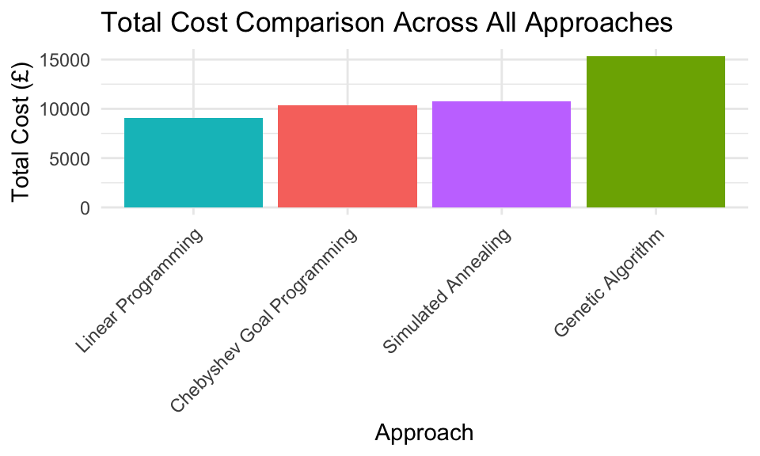

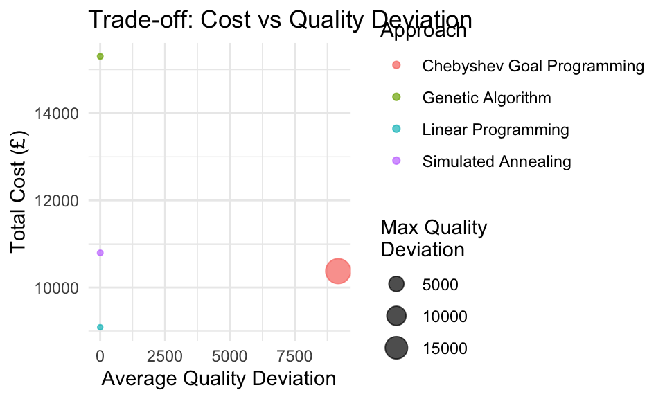

## 8.2 Key Findings

```
## === Key Findings ===
```

```
## 1. Cost Performance:
```

```
##    - LP provides the optimal cost baseline: £9087.69
```

```
##    - SA achieves 118.79% of LP cost
```

[output not shown]

```
##    - GA achieves 168.40% of LP cost
```

```
## 2. Quality Performance:
```

```
##    - Best average quality: Linear Programming (deviation: 0.3325)
```

```
## 3. Recommendation:
```

```
##    - Linear Programming provides the best cost-performance trade-off.
##    - For near-optimal solutions quickly, Simulated Annealing is valuable.
```

## 8.3 Solution Matrices Comparison

```
## === Solution Matrix Comparison (Sample: Blend 1) ===
```

Material allocation for Blend 1 across all approaches

| Material | LP | SA | Chebyshev_GP | GA |
| --- | --- | --- | --- | --- |
| R1 | 0.000 | 1,126.11441 | 0.000 | 460.88454 |
| R2 | 0.000 | 55.52575 | 0.000 | 111.94742 |
| R3 | 0.000 | 4,879.84982 | 0.000 | 1,970.02324 |
| R4 | 0.000 | 65.56893 | 0.000 | 125.04059 |
| R5 | 0.000 | 2,888.79410 | 0.000 | 2,147.27452 |
| R6 | 0.000 | 682.34280 | 0.000 | 2,046.69123 |
| R7 | 0.000 | 1,793.70073 | 0.000 | 1,544.82498 |
| R8 | 0.000 | 239.64480 | 0.000 | 69.59487 |
| R9 | 0.000 | 5,131.45110 | 0.000 | 1,454.06425 |
| R10 | 0.000 | 1,855.05480 | 0.000 | 1,422.85631 |
| R11 | 40,000.000 | 1,490.89164 | 40,000.000 | 3,351.50560 |
| R12 | 7,554.827 | 3,393.20786 | 32,528.357 | 11,955.95254 |
| R13 | 0.000 | 8,108.03091 | 0.000 | 9,270.89108 |
| R14 | 5,000.000 | 1,676.86150 | 0.000 | 631.92182 |
| R15 | 0.000 | 1,353.47688 | 0.000 | 569.72070 |
| R16 | 0.000 | 4,509.58783 | 0.000 | 1,373.26661 |
| R17 | 0.000 | 719.24393 | 0.000 | 2,297.57017 |
| R18 | 0.000 | 1,335.78955 | 3,328.753 | 2,224.34655 |
| R19 | 0.000 | 3,427.05893 | 0.000 | 1,467.51760 |
| R20 | 4,371.720 | 234.54991 | 0.000 | 5,454.56308 |
| R21 | 0.000 | 633.06835 | 0.000 | 6,509.52290 |
| R22 | 0.000 | 4,774.32558 | 0.000 | 4,082.29060 |
| R23 | 0.000 | 601.70127 | 0.000 | 405.42507 |
| R24 | 0.000 | 11.62515 | 0.000 | 88.93175 |
| R25 | 0.000 | 79.01195 | 0.000 | 60.50072 |
| R26 | 0.000 | 17.01871 | 0.000 | 132.39244 |
| R27 | 0.000 | 1,469.53193 | 0.000 | 4,940.00131 |
| R28 | 0.000 | 5,862.44619 | 0.000 | 6,278.80320 |
| R29 | 0.000 | 5,449.51299 | 0.000 | 3,531.39372 |
| R30 | 0.000 | 5,817.25380 | 0.000 | 2,469.32263 |
| R31 | 0.000 | 53.96965 | 0.000 | 341.20140 |
| R32 | 0.000 | 1,018.37400 | 0.000 | 451.88518 |
| R33 | 0.000 | 4,101.47470 | 0.000 | 1,194.64821 |
| R34 | 0.000 | 3,023.45370 | 0.000 | 1,102.81319 |
| R35 | 8,769.679 | 1,431.89785 | 0.000 | 314.30981 |
| R36 | 0.000 | 756.02662 | 0.000 | 1,147.60627 |
| R37 | 0.000 | 2,028.42133 | 0.000 | 1,161.24956 |
| R38 | 20,000.000 | 902.51724 | 14,133.729 | 2,820.12265 |
| R39 | 0.000 | 3,051.40534 | 0.000 | 1,402.45980 |
| R40 | 0.000 | 652.22836 | 0.000 | 76.07170 |
| R41 | 0.000 | 155.54720 | 0.000 | 581.05289 |
| R42 | 1,000.000 | 103.65421 | 0.000 | 95.56532 |
| R43 | 0.000 | 1,025.08226 | 0.000 | 472.91197 |
| R44 | 4,968.254 | 323.37563 | 0.000 | 206.62602 |
| R45 | 0.000 | 304.02253 | 0.000 | 544.23955 |
| R46 | 0.000 | 582.21087 | 0.000 | 303.12668 |
| R47 | 2,000.000 | 133.60433 | 0.000 | 279.89663 |
| R48 | 0.000 | 276.75870 | 0.000 | 74.41072 |
| R49 | 0.000 | 186.51857 | 0.000 | 123.78368 |
| R50 | 0.000 | 308.81743 | 0.000 | 93.31228 |
| R51 | 0.000 | 195.64513 | 0.000 | 144.89472 |
| R52 | 0.000 | 2,331.54779 | 0.000 | 441.09406 |
| R53 | 0.000 | 396.26121 | 0.000 | 840.35578 |
| R54 | 0.000 | 220.37277 | 0.000 | 96.71008 |
| R55 | 0.000 | 36.14129 | 0.000 | 115.45675 |
| R56 | 0.000 | 234.53821 | 0.000 | 97.99584 |
| R57 | 0.000 | 342.99250 | 0.000 | 267.55228 |
| R58 | 6,335.520 | 5,390.55179 | 10,009.162 | 6,698.61755 |
| R59 | 0.000 | 1,195.76392 | 0.000 | 976.76010 |
| R60 | 0.000 | 103.49492 | 0.000 | 47.39283 |

# 9 Conclusion

# 10 Appendix: Code Execution Notes

## 10.1 Required Libraries

All required R packages can be installed using:

```r
install.packages(c("dplyr", "Rglpk", "ompr", "ompr.roi", "ROI", "ROI.plugin.glpk",
                   "lpSolveAPI", "ggplot2", "GA", "knitr", "flextable", "tidyr"))
```

## 10.2 Reproducibility

This document uses real-world data from Fomeni<sup>[1]</sup>, ensuring consistent results across runs. Stochastic algorithms (Simulated Annealing and Genetic Algorithms) may produce slightly different results on each run due to their probabilistic nature, but the underlying data and deterministic algorithms (Linear Programming and Goal Programming) will produce identical results.

## 10.3 Parameter Tuning

Key parameters that can be adjusted: - **$\epsilon$ (epsilon)**: Tolerance for quality constraints (default: 0.5 for Fomeni data) - **SA parameters**: Initial temperature, cooling rate, iterations - **GA parameters**: Population size, generations, mutation/crossover rates - **Goal Programming weights**: Cost vs quality priorities

# 11 Appendix: Complete Recipe Matrices

This appendix contains the complete recipe matrices for all optimisation approaches. Each matrix shows the amount (in kg) of each raw material used in each blend.

## 11.1 Linear Programming Solution

```
## === LP Solution: Complete Recipe Matrix (x_ij in Kgs) ===
```

LP Solution: Amount of Each Material in Each Blend (60 materials × 10 blends)

| Material | B1 | B2 | B3 | B4 | B5 | B6 | B7 | B8 | B9 | B10 |
| --- | --- | --- | --- | --- | --- | --- | --- | --- | --- | --- |
| R1 | 0.000 | 0.00000 | 0.000 | 5,000.000 | 0.000 | 0.0000 | 0.0000 | 0.0000 | 0.000 | 0 |
| R2 | 0.000 | 0.00000 | 0.000 | 0.000 | 0.000 | 0.0000 | 0.0000 | 0.0000 | 1,000.000 | 0 |
| R3 | 0.000 | 0.00000 | 20,450.410 | 0.000 | 4,549.590 | 0.0000 | 0.0000 | 0.0000 | 0.000 | 0 |
| R4 | 0.000 | 0.00000 | 0.000 | 0.000 | 1,000.000 | 0.0000 | 0.0000 | 0.0000 | 0.000 | 0 |
| R5 | 0.000 | 0.00000 | 0.000 | 0.000 | 0.000 | 0.0000 | 0.0000 | 0.0000 | 0.000 | 0 |
| R6 | 0.000 | 0.00000 | 0.000 | 0.000 | 0.000 | 0.0000 | 0.0000 | 0.0000 | 6,333.333 | 0 |
| R7 | 0.000 | 0.00000 | 0.000 | 20,000.000 | 0.000 | 0.0000 | 0.0000 | 0.0000 | 0.000 | 0 |
| R8 | 0.000 | 0.00000 | 0.000 | 0.000 | 0.000 | 0.0000 | 0.0000 | 0.0000 | 1,000.000 | 0 |
| R9 | 0.000 | 0.00000 | 2,207.300 | 0.000 | 0.000 | 0.0000 | 0.0000 | 0.0000 | 0.000 | 0 |
| R10 | 0.000 | 0.00000 | 0.000 | 0.000 | 0.000 | 15,000.0000 | 0.0000 | 0.0000 | 0.000 | 0 |
| R11 | 40,000.000 | 0.00000 | 0.000 | 0.000 | 0.000 | 0.0000 | 0.0000 | 0.0000 | 0.000 | 0 |
| R12 | 7,554.827 | 50,277.77778 | 0.000 | 0.000 | 0.000 | 0.0000 | 0.0000 | 0.0000 | 0.000 | 0 |
| R13 | 0.000 | 0.00000 | 0.000 | 4,164.021 | 0.000 | 0.0000 | 0.0000 | 0.0000 | 0.000 | 0 |
| R14 | 5,000.000 | 0.00000 | 0.000 | 0.000 | 0.000 | 0.0000 | 0.0000 | 0.0000 | 0.000 | 0 |
| R15 | 0.000 | 0.00000 | 0.000 | 0.000 | 0.000 | 0.0000 | 2,333.3333 | 2,666.6667 | 0.000 | 0 |
| R16 | 0.000 | 0.00000 | 0.000 | 0.000 | 1,250.000 | 0.0000 | 0.0000 | 0.0000 | 0.000 | 18,750 |
| R17 | 0.000 | 0.00000 | 0.000 | 0.000 | 0.000 | 0.0000 | 0.0000 | 833.3333 | 0.000 | 0 |
| R18 | 0.000 | 20,000.00000 | 0.000 | 0.000 | 0.000 | 0.0000 | 0.0000 | 0.0000 | 0.000 | 0 |
| R19 | 0.000 | 3,746.03175 | 0.000 | 16,253.968 | 0.000 | 0.0000 | 0.0000 | 0.0000 | 0.000 | 0 |
| R20 | 4,371.720 | 0.00000 | 11,543.614 | 0.000 | 24,084.666 | 0.0000 | 0.0000 | 0.0000 | 0.000 | 0 |
| R21 | 0.000 | 0.00000 | 0.000 | 0.000 | 13,384.326 | 0.0000 | 0.0000 | 0.0000 | 0.000 | 0 |
| R22 | 0.000 | 0.00000 | 0.000 | 19,666.667 | 0.000 | 333.3333 | 0.0000 | 0.0000 | 0.000 | 0 |
| R23 | 0.000 | 0.00000 | 0.000 | 0.000 | 0.000 | 0.0000 | 0.0000 | 0.0000 | 0.000 | 0 |
| R24 | 0.000 | 0.00000 | 0.000 | 0.000 | 0.000 | 0.0000 | 0.0000 | 0.0000 | 0.000 | 0 |
| R25 | 0.000 | 0.00000 | 0.000 | 500.000 | 0.000 | 0.0000 | 0.0000 | 0.0000 | 0.000 | 0 |
| R26 | 0.000 | 0.00000 | 1,000.000 | 0.000 | 0.000 | 0.0000 | 0.0000 | 0.0000 | 0.000 | 0 |
| R27 | 0.000 | 0.00000 | 19,170.041 | 6,082.011 | 14,747.948 | 0.0000 | 0.0000 | 0.0000 | 0.000 | 0 |
| R28 | 0.000 | 0.00000 | 0.000 | 7,333.333 | 0.000 | 32,666.6667 | 0.0000 | 0.0000 | 0.000 | 0 |
| R29 | 0.000 | 0.00000 | 0.000 | 0.000 | 0.000 | 0.0000 | 0.0000 | 0.0000 | 0.000 | 0 |
| R30 | 0.000 | 0.00000 | 0.000 | 0.000 | 0.000 | 0.0000 | 338.9831 | 0.0000 | 0.000 | 0 |
| R31 | 0.000 | 0.00000 | 0.000 | 5,000.000 | 0.000 | 0.0000 | 0.0000 | 0.0000 | 0.000 | 0 |
| R32 | 0.000 | 0.00000 | 3,333.333 | 0.000 | 0.000 | 0.0000 | 0.0000 | 0.0000 | 1,666.667 | 0 |
| R33 | 0.000 | 0.00000 | 0.000 | 0.000 | 0.000 | 0.0000 | 4,615.8192 | 0.0000 | 0.000 | 0 |
| R34 | 0.000 | 0.00000 | 0.000 | 0.000 | 9,500.000 | 0.0000 | 0.0000 | 500.0000 | 0.000 | 0 |
| R35 | 8,769.679 | 0.00000 | 0.000 | 0.000 | 0.000 | 0.0000 | 0.0000 | 0.0000 | 0.000 | 0 |
| R36 | 0.000 | 7,523.80952 | 0.000 | 0.000 | 0.000 | 0.0000 | 2,118.6441 | 0.0000 | 0.000 | 0 |
| R37 | 0.000 | 0.00000 | 0.000 | 10,000.000 | 0.000 | 0.0000 | 0.0000 | 0.0000 | 0.000 | 0 |
| R38 | 20,000.000 | 0.00000 | 0.000 | 0.000 | 0.000 | 0.0000 | 0.0000 | 0.0000 | 0.000 | 0 |
| R39 | 0.000 | 0.00000 | 0.000 | 0.000 | 0.000 | 0.0000 | 0.0000 | 0.0000 | 0.000 | 0 |
| R40 | 0.000 | 0.00000 | 0.000 | 0.000 | 2,000.000 | 0.0000 | 0.0000 | 0.0000 | 0.000 | 0 |
| R41 | 0.000 | 0.00000 | 0.000 | 0.000 | 0.000 | 0.0000 | 0.0000 | 0.0000 | 0.000 | 0 |
| R42 | 1,000.000 | 0.00000 | 0.000 | 0.000 | 0.000 | 0.0000 | 0.0000 | 0.0000 | 0.000 | 0 |
| R43 | 0.000 | 0.00000 | 0.000 | 5,000.000 | 0.000 | 0.0000 | 0.0000 | 0.0000 | 0.000 | 0 |
| R44 | 4,968.254 | 31.74603 | 0.000 | 0.000 | 0.000 | 0.0000 | 0.0000 | 0.0000 | 0.000 | 0 |
| R45 | 0.000 | 0.00000 | 0.000 | 0.000 | 1,489.625 | 0.0000 | 0.0000 | 0.0000 | 0.000 | 0 |
| R46 | 0.000 | 0.00000 | 0.000 | 0.000 | 0.000 | 2,000.0000 | 0.0000 | 0.0000 | 0.000 | 0 |
| R47 | 2,000.000 | 0.00000 | 0.000 | 0.000 | 0.000 | 0.0000 | 0.0000 | 0.0000 | 0.000 | 0 |
| R48 | 0.000 | 1,000.00000 | 0.000 | 0.000 | 0.000 | 0.0000 | 0.0000 | 0.0000 | 0.000 | 0 |
| R49 | 0.000 | 1,000.00000 | 0.000 | 0.000 | 0.000 | 0.0000 | 0.0000 | 0.0000 | 0.000 | 0 |
| R50 | 0.000 | 1,000.00000 | 0.000 | 0.000 | 0.000 | 0.0000 | 0.0000 | 0.0000 | 0.000 | 0 |
| R51 | 0.000 | 0.00000 | 0.000 | 0.000 | 0.000 | 0.0000 | 0.0000 | 0.0000 | 0.000 | 0 |
| R52 | 0.000 | 0.00000 | 0.000 | 0.000 | 5,000.000 | 0.0000 | 0.0000 | 0.0000 | 0.000 | 0 |
| R53 | 0.000 | 0.00000 | 0.000 | 0.000 | 0.000 | 0.0000 | 0.0000 | 0.0000 | 0.000 | 0 |
| R54 | 0.000 | 0.00000 | 0.000 | 0.000 | 0.000 | 0.0000 | 593.2203 | 0.0000 | 0.000 | 0 |
| R55 | 0.000 | 0.00000 | 0.000 | 1,000.000 | 0.000 | 0.0000 | 0.0000 | 0.0000 | 0.000 | 0 |
| R56 | 0.000 | 0.00000 | 0.000 | 0.000 | 0.000 | 0.0000 | 0.0000 | 1,000.0000 | 0.000 | 0 |
| R57 | 0.000 | 0.00000 | 2,295.301 | 0.000 | 0.000 | 0.0000 | 0.0000 | 0.0000 | 0.000 | 0 |
| R58 | 6,335.520 | 9,420.63492 | 0.000 | 0.000 | 22,993.845 | 0.0000 | 0.0000 | 0.0000 | 0.000 | 1,250 |
| R59 | 0.000 | 5,000.00000 | 0.000 | 0.000 | 0.000 | 0.0000 | 0.0000 | 0.0000 | 0.000 | 0 |
| R60 | 0.000 | 1,000.00000 | 0.000 | 0.000 | 0.000 | 0.0000 | 0.0000 | 0.0000 | 0.000 | 0 |

## 11.2 Simulated Annealing Solution

```
## === SA Solution: Complete Recipe Matrix (x_ij in Kgs) ===
```

SA Solution: Amount of Each Material in Each Blend (60 materials × 10 blends)

| Material | B1 | B2 | B3 | B4 | B5 | B6 | B7 | B8 | B9 | B10 |
| --- | --- | --- | --- | --- | --- | --- | --- | --- | --- | --- |
| R1 | 1,126.11441 | 1,338.96037 | 412.848352 | 980.433616 | 314.882501 | 466.338371 | 104.041150 | 26.219244 | 66.3197340 | 45.091593 |
| R2 | 55.52575 | 213.14862 | 132.362711 | 285.543730 | 175.192246 | 17.315706 | 10.348215 | 7.988559 | 21.6206263 | 36.543368 |
| R3 | 4,879.84982 | 1,507.95195 | 322.562012 | 279.580571 | 5,283.849345 | 1,875.267216 | 103.955639 | 140.026649 | 265.0947163 | 1,086.607635 |
| R4 | 65.56893 | 71.33213 | 71.984513 | 205.461491 | 337.631257 | 135.300121 | 5.031082 | 22.581918 | 0.9637699 | 43.004086 |
| R5 | 2,888.79410 | 6,070.12285 | 1,560.068805 | 6,254.653205 | 4,189.107365 | 1,731.894417 | 526.030758 | 241.265107 | 265.5241323 | 164.943396 |
| R6 | 682.34280 | 1,074.52465 | 1,479.933887 | 1,709.674253 | 3,698.687356 | 990.442236 | 358.966192 | 234.468131 | 511.4692992 | 344.144796 |
| R7 | 1,793.70073 | 1,427.05140 | 3,025.889877 | 4,746.130516 | 2,860.553988 | 1,716.954631 | 32.894819 | 45.592649 | 500.2296069 | 810.124815 |
| R8 | 239.64480 | 224.89489 | 132.511113 | 51.614143 | 139.540503 | 85.084278 | 11.751491 | 11.411347 | 2.9475670 | 32.430556 |
| R9 | 5,131.45110 | 263.30616 | 1,042.784179 | 4,033.594834 | 1,523.504055 | 1,925.487296 | 28.410995 | 114.170330 | 380.7034079 | 556.587648 |
| R10 | 1,855.05480 | 891.36978 | 3,165.663869 | 1,049.427192 | 5,048.806935 | 779.625884 | 220.097086 | 8.743970 | 104.3939134 | 600.954406 |
| R11 | 1,490.89164 | 7,727.78621 | 2,790.830267 | 2,212.187799 | 4,887.327832 | 3.649088 | 796.557032 | 328.815729 | 435.7653359 | 674.480140 |
| R12 | 3,393.20786 | 4,218.37055 | 1,059.486895 | 5,336.463252 | 6,697.348583 | 2,961.172851 | 731.027390 | 187.542099 | 498.5560867 | 1,137.484060 |
| R13 | 8,108.03091 | 468.68473 | 2,332.607711 | 1,598.515324 | 1,869.617386 | 2,467.601585 | 213.569989 | 293.504764 | 543.0754330 | 383.056506 |
| R14 | 1,676.86150 | 104.70851 | 394.497791 | 1,238.823815 | 353.775266 | 477.492134 | 296.181867 | 42.520758 | 175.7448965 | 62.562769 |
| R15 | 1,353.47688 | 380.19374 | 574.555766 | 136.053370 | 1,194.567682 | 748.299235 | 197.970675 | 89.409202 | 39.6221886 | 249.751711 |
| R16 | 4,509.58783 | 3,936.89001 | 1,658.360683 | 3,018.500968 | 3,123.853332 | 1,298.836259 | 117.612941 | 30.403231 | 279.0108739 | 721.151195 |
| R17 | 719.24393 | 4,522.41772 | 2,326.914608 | 6,320.203963 | 3,234.113822 | 504.998083 | 558.817984 | 144.648049 | 366.3337833 | 890.999584 |
| R18 | 1,335.78955 | 655.35526 | 663.866175 | 2,619.193023 | 1,108.944011 | 518.058154 | 444.242905 | 266.414811 | 104.8319478 | 459.746609 |
| R19 | 3,427.05893 | 803.00334 | 3,948.760482 | 3,827.077463 | 946.043153 | 1,925.183028 | 198.771314 | 14.699561 | 397.0426750 | 679.367244 |
| R20 | 234.54991 | 926.36706 | 311.483439 | 4,114.363294 | 7,881.247298 | 2,464.058952 | 170.372186 | 134.755146 | 555.5833944 | 1,346.897183 |
| R21 | 633.06835 | 6,009.37586 | 908.166550 | 7,373.108270 | 2,938.048840 | 4,335.916046 | 172.248189 | 210.083732 | 389.6103722 | 645.109802 |
| R22 | 4,774.32558 | 5,029.67027 | 2,797.283113 | 401.732526 | 4,708.093646 | 935.188712 | 332.533896 | 51.790708 | 112.3926728 | 655.419418 |
| R23 | 601.70127 | 1,224.95748 | 660.025967 | 674.779174 | 1,347.704749 | 204.672892 | 52.152102 | 58.341985 | 53.3783439 | 117.672424 |
| R24 | 11.62515 | 209.22016 | 63.228320 | 260.879913 | 35.453404 | 247.399765 | 36.293561 | 13.695910 | 41.9616786 | 71.959785 |
| R25 | 79.01195 | 104.45830 | 99.146810 | 15.860622 | 51.182318 | 103.459267 | 4.197843 | 3.120257 | 13.3516050 | 17.875060 |
| R26 | 17.01871 | 334.00590 | 32.708546 | 351.787901 | 8.262264 | 168.802051 | 16.162516 | 4.467952 | 29.8489321 | 36.666949 |
| R27 | 1,469.53193 | 2,150.05601 | 3,166.635562 | 5,925.529433 | 2,436.264992 | 3,441.773197 | 111.919300 | 15.926934 | 703.5964521 | 479.643414 |
| R28 | 5,862.44619 | 6,155.13464 | 2,882.845475 | 2,714.432300 | 6,546.973143 | 31.147888 | 84.745756 | 154.864145 | 439.0556636 | 533.228341 |
| R29 | 5,449.51299 | 3,988.43868 | 2,028.602763 | 408.664610 | 574.704941 | 1,174.137369 | 390.498160 | 123.486943 | 74.1518970 | 1,210.332956 |
| R30 | 5,817.25380 | 1,904.36094 | 2,784.473662 | 5,608.949919 | 1,058.897932 | 3,659.474010 | 193.869199 | 282.202331 | 708.8347552 | 456.010030 |
| R31 | 53.96965 | 652.42516 | 976.954382 | 1,421.263066 | 846.851533 | 184.782360 | 35.781962 | 69.264888 | 163.0041818 | 271.021116 |
| R32 | 1,018.37400 | 1,324.11147 | 492.508859 | 65.444332 | 1,187.856424 | 546.744219 | 149.503760 | 44.756385 | 77.6256130 | 93.074936 |
| R33 | 4,101.47470 | 1,889.14480 | 1,023.770820 | 1,222.884249 | 407.054333 | 352.288874 | 154.311545 | 105.868483 | 229.4237914 | 512.519254 |
| R34 | 3,023.45370 | 913.11365 | 1,208.404015 | 1,340.257562 | 2,117.967557 | 604.856056 | 72.734055 | 73.985827 | 105.6393810 | 382.898568 |
| R35 | 1,431.89785 | 2,771.84716 | 869.398685 | 1,745.790119 | 1,765.014643 | 965.323943 | 91.281256 | 128.541362 | 160.5262248 | 70.378765 |
| R36 | 756.02662 | 3,342.38967 | 1,548.769904 | 2,634.304630 | 308.708017 | 348.579489 | 250.975868 | 42.355929 | 50.2843259 | 532.407852 |
| R37 | 2,028.42133 | 2,512.54050 | 1,728.192251 | 1,526.859782 | 117.271268 | 1,489.040297 | 99.601002 | 261.822595 | 29.1307630 | 103.748782 |
| R38 | 902.51724 | 4,172.21412 | 926.713886 | 4,044.338012 | 126.236601 | 838.697215 | 853.627620 | 320.152647 | 257.5815905 | 1,176.173585 |
| R39 | 3,051.40534 | 1,936.96693 | 1,735.679970 | 1,301.033009 | 3,942.940110 | 2,035.784780 | 456.115891 | 5.569639 | 42.2625634 | 355.560728 |
| R40 | 652.22836 | 162.45977 | 11.534684 | 534.328938 | 154.291711 | 259.200795 | 39.407897 | 27.708727 | 39.0767743 | 107.403870 |
| R41 | 155.54720 | 1,738.40754 | 534.361220 | 783.534407 | 159.159821 | 608.757212 | 199.911852 | 6.516352 | 126.8965714 | 324.718022 |
| R42 | 103.65421 | 221.53165 | 20.963604 | 298.905944 | 158.564476 | 105.922359 | 29.135981 | 2.366364 | 17.5220384 | 12.002006 |
| R43 | 1,025.08226 | 1,253.43817 | 226.474126 | 1,309.836278 | 576.711773 | 102.592390 | 119.112708 | 35.739566 | 34.9157898 | 56.193847 |
| R44 | 323.37563 | 435.23669 | 152.902589 | 1,654.866928 | 1,170.888403 | 573.303039 | 243.446331 | 12.613955 | 59.0869944 | 249.152593 |
| R45 | 304.02253 | 1,212.42680 | 410.184554 | 1,578.569564 | 223.323708 | 571.625088 | 126.215014 | 1.682659 | 1.2347184 | 222.361127 |
| R46 | 582.21087 | 372.19192 | 71.888908 | 393.624674 | 181.075053 | 276.069353 | 9.002706 | 29.935128 | 33.7989232 | 50.202464 |
| R47 | 133.60433 | 634.38544 | 107.478874 | 452.646616 | 143.191770 | 261.367893 | 38.614353 | 18.649094 | 23.8994662 | 62.059191 |
| R48 | 276.75870 | 273.35165 | 46.506363 | 54.275320 | 234.841434 | 27.566101 | 16.712629 | 2.089671 | 22.4337625 | 2.728287 |
| R49 | 186.51857 | 396.63205 | 49.984214 | 62.811509 | 134.803599 | 81.211880 | 7.838836 | 4.942454 | 27.3182263 | 34.648354 |
| R50 | 308.81743 | 60.99750 | 64.927975 | 158.406958 | 298.734370 | 7.272477 | 8.684393 | 17.026339 | 24.7526822 | 48.973852 |
| R51 | 195.64513 | 55.93209 | 51.183046 | 174.332126 | 328.078216 | 132.118222 | 3.720932 | 2.458748 | 7.3341365 | 49.197350 |
| R52 | 2,331.54779 | 1,348.34132 | 542.887929 | 2.568834 | 80.578896 | 207.249353 | 74.954979 | 110.279083 | 27.0623364 | 261.965693 |
| R53 | 396.26121 | 1,194.25290 | 490.842140 | 1,193.320877 | 707.217158 | 444.396470 | 182.238096 | 69.698082 | 29.4684757 | 62.189391 |
| R54 | 220.37277 | 231.67741 | 65.444463 | 90.644726 | 223.595906 | 97.880907 | 27.522464 | 5.657007 | 7.2967581 | 15.528436 |
| R55 | 36.14129 | 439.87213 | 3.487026 | 74.746941 | 190.379062 | 159.574662 | 15.461129 | 17.369834 | 28.9314433 | 24.734275 |
| R56 | 234.53821 | 181.72092 | 32.663433 | 313.297109 | 89.567549 | 83.883365 | 26.363561 | 13.777618 | 1.5454064 | 22.642831 |
| R57 | 342.99250 | 1,321.40139 | 361.777731 | 1,092.425459 | 1,048.205752 | 414.134595 | 57.314517 | 20.436281 | 67.8073352 | 45.109967 |
| R58 | 5,390.55179 | 3,433.34538 | 3,802.620872 | 149.739288 | 7,515.533879 | 1,118.836883 | 149.972159 | 215.643385 | 278.9371291 | 86.379658 |
| R59 | 1,195.76392 | 1,289.33634 | 826.015743 | 296.369129 | 850.281577 | 50.418066 | 19.640557 | 33.671676 | 112.5870549 | 173.907196 |
| R60 | 103.49492 | 292.18932 | 51.333653 | 275.353123 | 136.895256 | 84.235321 | 2.584078 | 2.128537 | 2.8681525 | 40.270522 |

## 11.3 Chebyshev Goal Programming Solution

```
## === Chebyshev GP Solution: Complete Recipe Matrix (x_ij in Kgs) ===
```

Chebyshev GP Solution: Amount of Each Material in Each Blend (60 materials × 10 blends)

| Material | B1 | B2 | B3 | B4 | B5 | B6 | B7 | B8 | B9 | B10 |
| --- | --- | --- | --- | --- | --- | --- | --- | --- | --- | --- |
| R1 | 0.000 | 0.0000 | 0.0000 | 0.0000 | 0.0000 | 0.000 | 0 | 0 | 0 | 0.0000 |
| R2 | 0.000 | 0.0000 | 0.0000 | 1,000.0000 | 0.0000 | 0.000 | 0 | 0 | 0 | 0.0000 |
| R3 | 0.000 | 0.0000 | 0.0000 | 0.0000 | 0.0000 | 0.000 | 0 | 0 | 0 | 0.0000 |
| R4 | 0.000 | 0.0000 | 0.0000 | 1,000.0000 | 0.0000 | 0.000 | 0 | 0 | 0 | 0.0000 |
| R5 | 0.000 | 0.0000 | 1,234.6787 | 0.0000 | 0.0000 | 0.000 | 0 | 0 | 0 | 0.0000 |
| R6 | 0.000 | 0.0000 | 7,958.0429 | 0.0000 | 12,041.9571 | 0.000 | 0 | 0 | 0 | 0.0000 |
| R7 | 0.000 | 0.0000 | 8,359.9383 | 0.0000 | 0.0000 | 1,890.062 | 0 | 0 | 9,750 | 0.0000 |
| R8 | 0.000 | 0.0000 | 0.0000 | 0.0000 | 0.0000 | 1,000.000 | 0 | 0 | 0 | 0.0000 |
| R9 | 0.000 | 102.3406 | 0.0000 | 14,897.6594 | 0.0000 | 0.000 | 0 | 0 | 0 | 0.0000 |
| R10 | 0.000 | 0.0000 | 0.0000 | 15,000.0000 | 0.0000 | 0.000 | 0 | 0 | 0 | 0.0000 |
| R11 | 40,000.000 | 0.0000 | 0.0000 | 0.0000 | 0.0000 | 0.000 | 0 | 0 | 0 | 0.0000 |
| R12 | 32,528.357 | 38,998.6023 | 0.0000 | 0.0000 | 8,473.0411 | 0.000 | 0 | 0 | 0 | 0.0000 |
| R13 | 0.000 | 0.0000 | 0.0000 | 0.0000 | 0.0000 | 0.000 | 0 | 1,100 | 0 | 0.0000 |
| R14 | 0.000 | 0.0000 | 0.0000 | 0.0000 | 0.0000 | 0.000 | 5,000 | 0 | 0 | 0.0000 |
| R15 | 0.000 | 0.0000 | 0.0000 | 0.0000 | 0.0000 | 0.000 | 0 | 0 | 0 | 0.0000 |
| R16 | 0.000 | 1,231.6725 | 0.0000 | 0.0000 | 0.0000 | 0.000 | 0 | 0 | 0 | 18,768.3275 |
| R17 | 0.000 | 0.0000 | 0.0000 | 0.0000 | 0.0000 | 3,082.454 | 3,000 | 3,900 | 0 | 0.0000 |
| R18 | 3,328.753 | 0.0000 | 0.0000 | 0.0000 | 16,671.2474 | 0.000 | 0 | 0 | 0 | 0.0000 |
| R19 | 0.000 | 0.0000 | 0.0000 | 0.0000 | 20,000.0000 | 0.000 | 0 | 0 | 0 | 0.0000 |
| R20 | 0.000 | 0.0000 | 0.0000 | 40,000.0000 | 0.0000 | 0.000 | 0 | 0 | 0 | 0.0000 |
| R21 | 0.000 | 18,417.3750 | 18,134.9499 | 3,447.6751 | 0.0000 | 0.000 | 0 | 0 | 0 | 0.0000 |
| R22 | 0.000 | 0.0000 | 0.0000 | 7,615.9712 | 7,509.4432 | 0.000 | 0 | 0 | 0 | 0.0000 |
| R23 | 0.000 | 0.0000 | 0.0000 | 5,000.0000 | 0.0000 | 0.000 | 0 | 0 | 0 | 0.0000 |
| R24 | 0.000 | 0.0000 | 0.0000 | 0.0000 | 516.0415 | 0.000 | 0 | 0 | 0 | 0.0000 |
| R25 | 0.000 | 0.0000 | 0.0000 | 0.0000 | 500.0000 | 0.000 | 0 | 0 | 0 | 0.0000 |
| R26 | 0.000 | 0.0000 | 0.0000 | 0.0000 | 0.0000 | 0.000 | 0 | 0 | 0 | 0.0000 |
| R27 | 0.000 | 0.0000 | 21,460.7884 | 0.0000 | 0.0000 | 14,027.485 | 0 | 0 | 0 | 0.0000 |
| R28 | 0.000 | 0.0000 | 0.0000 | 0.0000 | 0.0000 | 0.000 | 0 | 0 | 0 | 0.0000 |
| R29 | 0.000 | 0.0000 | 0.0000 | 0.0000 | 0.0000 | 25,000.000 | 0 | 0 | 0 | 0.0000 |
| R30 | 0.000 | 0.0000 | 0.0000 | 0.0000 | 0.0000 | 0.000 | 0 | 0 | 0 | 0.0000 |
| R31 | 0.000 | 0.0000 | 0.0000 | 0.0000 | 0.0000 | 0.000 | 0 | 0 | 0 | 0.0000 |
| R32 | 0.000 | 0.0000 | 0.0000 | 0.0000 | 0.0000 | 5,000.000 | 0 | 0 | 0 | 0.0000 |
| R33 | 0.000 | 0.0000 | 0.0000 | 0.0000 | 0.0000 | 0.000 | 2,000 | 0 | 0 | 0.0000 |
| R34 | 0.000 | 0.0000 | 0.0000 | 0.0000 | 0.0000 | 0.000 | 0 | 0 | 0 | 0.0000 |
| R35 | 0.000 | 0.0000 | 0.0000 | 0.0000 | 624.2942 | 0.000 | 0 | 0 | 0 | 0.0000 |
| R36 | 0.000 | 4,571.0624 | 0.0000 | 0.0000 | 0.0000 | 0.000 | 0 | 0 | 0 | 0.0000 |
| R37 | 0.000 | 0.0000 | 0.0000 | 0.0000 | 0.0000 | 0.000 | 0 | 0 | 0 | 0.0000 |
| R38 | 14,133.729 | 0.0000 | 0.0000 | 1,902.9377 | 0.0000 | 0.000 | 0 | 0 | 0 | 0.0000 |
| R39 | 0.000 | 0.0000 | 0.0000 | 0.0000 | 15,000.0000 | 0.000 | 0 | 0 | 0 | 0.0000 |
| R40 | 0.000 | 2,000.0000 | 0.0000 | 0.0000 | 0.0000 | 0.000 | 0 | 0 | 0 | 0.0000 |
| R41 | 0.000 | 0.0000 | 0.0000 | 0.0000 | 0.0000 | 0.000 | 0 | 0 | 0 | 0.0000 |
| R42 | 0.000 | 0.0000 | 339.4425 | 0.0000 | 0.0000 | 0.000 | 0 | 0 | 250 | 410.5575 |
| R43 | 0.000 | 0.0000 | 0.0000 | 0.0000 | 5,000.0000 | 0.000 | 0 | 0 | 0 | 0.0000 |
| R44 | 0.000 | 0.0000 | 0.0000 | 522.9126 | 4,477.0874 | 0.000 | 0 | 0 | 0 | 0.0000 |
| R45 | 0.000 | 0.0000 | 0.0000 | 0.0000 | 5,000.0000 | 0.000 | 0 | 0 | 0 | 0.0000 |
| R46 | 0.000 | 0.0000 | 0.0000 | 2,000.0000 | 0.0000 | 0.000 | 0 | 0 | 0 | 0.0000 |
| R47 | 0.000 | 0.0000 | 0.0000 | 0.0000 | 2,000.0000 | 0.000 | 0 | 0 | 0 | 0.0000 |
| R48 | 0.000 | 1,000.0000 | 0.0000 | 0.0000 | 0.0000 | 0.000 | 0 | 0 | 0 | 0.0000 |
| R49 | 0.000 | 0.0000 | 0.0000 | 1,000.0000 | 0.0000 | 0.000 | 0 | 0 | 0 | 0.0000 |
| R50 | 0.000 | 0.0000 | 0.0000 | 1,000.0000 | 0.0000 | 0.000 | 0 | 0 | 0 | 0.0000 |
| R51 | 0.000 | 0.0000 | 0.0000 | 0.0000 | 0.0000 | 0.000 | 0 | 0 | 0 | 821.1150 |
| R52 | 0.000 | 2,487.8407 | 2,512.1593 | 0.0000 | 0.0000 | 0.000 | 0 | 0 | 0 | 0.0000 |
| R53 | 0.000 | 0.0000 | 0.0000 | 0.0000 | 0.0000 | 0.000 | 0 | 0 | 0 | 0.0000 |
| R54 | 0.000 | 0.0000 | 0.0000 | 1,000.0000 | 0.0000 | 0.000 | 0 | 0 | 0 | 0.0000 |
| R55 | 0.000 | 529.7838 | 0.0000 | 470.2162 | 0.0000 | 0.000 | 0 | 0 | 0 | 0.0000 |
| R56 | 0.000 | 754.9784 | 0.0000 | 245.0216 | 0.0000 | 0.000 | 0 | 0 | 0 | 0.0000 |
| R57 | 0.000 | 0.0000 | 0.0000 | 0.0000 | 0.0000 | 0.000 | 0 | 0 | 0 | 0.0000 |
| R58 | 10,009.162 | 28,906.3443 | 0.0000 | 0.0000 | 1,084.4942 | 0.000 | 0 | 0 | 0 | 0.0000 |
| R59 | 0.000 | 0.0000 | 0.0000 | 3,897.6061 | 1,102.3939 | 0.000 | 0 | 0 | 0 | 0.0000 |
| R60 | 0.000 | 1,000.0000 | 0.0000 | 0.0000 | 0.0000 | 0.000 | 0 | 0 | 0 | 0.0000 |

## 11.4 Genetic Algorithm Solution

```
## === GA Solution: Complete Recipe Matrix (x_ij in Kgs) ===
```

GA Solution: Amount of Each Material in Each Blend (60 materials × 10 blends)

| Material | B1 | B2 | B3 | B4 | B5 | B6 | B7 | B8 | B9 | B10 |
| --- | --- | --- | --- | --- | --- | --- | --- | --- | --- | --- |
| R1 | 460.88454 | 670.02422 | 628.20620 | 416.79009 | 409.65373 | 655.95805 | 443.74806 | 477.15771 | 423.62575 | 422.68989 |
| R2 | 111.94742 | 23.13334 | 50.49263 | 192.48014 | 170.58514 | 97.68968 | 95.08269 | 78.61300 | 106.73281 | 76.18339 |
| R3 | 1,970.02324 | 4,099.49882 | 3,055.64443 | 2,281.79285 | 1,616.05297 | 2,901.71623 | 2,214.43695 | 935.15693 | 2,761.73442 | 3,202.39024 |
| R4 | 125.04059 | 50.64189 | 110.93152 | 109.96361 | 78.71518 | 127.48642 | 97.42686 | 91.20211 | 93.88025 | 116.17742 |
| R5 | 2,147.27452 | 4,278.27932 | 1,207.73162 | 2,782.69691 | 3,812.67130 | 4,022.09288 | 1,403.79178 | 1,393.96141 | 2,680.26927 | 1,347.21426 |
| R6 | 2,046.69123 | 2,598.59889 | 1,776.89160 | 2,381.17475 | 2,700.65508 | 1,212.19850 | 2,492.33021 | 1,620.92723 | 1,870.22587 | 1,352.94949 |
| R7 | 1,544.82498 | 1,456.57952 | 1,915.51304 | 1,659.48478 | 2,414.36140 | 2,438.18317 | 2,131.89671 | 2,553.41188 | 2,356.57690 | 1,573.86438 |
| R8 | 69.59487 | 99.26477 | 90.60618 | 77.34426 | 99.43777 | 111.18760 | 140.79227 | 141.74546 | 58.56496 | 113.40994 |
| R9 | 1,454.06425 | 1,620.81594 | 1,285.90679 | 1,506.17028 | 417.53221 | 2,326.10062 | 1,633.35247 | 1,605.99308 | 1,805.23326 | 1,356.29767 |
| R10 | 1,422.85631 | 1,477.73117 | 1,650.10198 | 1,646.45200 | 1,592.84329 | 1,412.24305 | 1,805.42127 | 2,022.61099 | 1,221.77115 | 778.86756 |
| R11 | 3,351.50560 | 5,337.44019 | 6,302.55434 | 2,937.36936 | 8,091.95156 | 2,395.02693 | 2,991.86261 | 3,264.46210 | 843.23407 | 4,635.64210 |
| R12 | 11,955.95254 | 12,834.34933 | 4,142.83187 | 14,098.23727 | 10,253.02129 | 3,639.80728 | 5,506.67793 | 6,164.92780 | 5,535.80412 | 6,076.35297 |
| R13 | 9,270.89108 | 7,958.85423 | 3,069.79289 | 8,974.49949 | 8,614.13854 | 3,120.60152 | 5,308.35587 | 3,839.29243 | 4,978.34714 | 5,032.23878 |
| R14 | 631.92182 | 292.42408 | 490.64513 | 336.66221 | 408.50487 | 686.59217 | 645.90647 | 413.19607 | 622.63764 | 479.19764 |
| R15 | 569.72070 | 708.76579 | 547.97458 | 503.79047 | 552.52184 | 471.22809 | 548.98800 | 406.72097 | 386.30683 | 315.23635 |
| R16 | 1,373.26661 | 2,694.40851 | 2,660.95199 | 1,625.06714 | 2,351.04111 | 2,387.16513 | 2,135.28869 | 2,072.27773 | 1,517.20238 | 1,230.33850 |
| R17 | 2,297.57017 | 1,838.99238 | 2,286.80361 | 2,633.58660 | 2,809.15573 | 1,839.30684 | 2,186.57055 | 1,414.13220 | 1,332.09103 | 1,414.19015 |
| R18 | 2,224.34655 | 1,836.38036 | 1,878.96147 | 2,934.16821 | 1,704.30490 | 1,383.10114 | 1,691.92155 | 1,533.93818 | 2,041.35049 | 2,805.28487 |
| R19 | 1,467.51760 | 2,841.10183 | 1,620.18030 | 2,321.19149 | 3,501.61633 | 635.28380 | 2,954.25485 | 1,286.12395 | 1,930.76010 | 1,508.78357 |
| R20 | 5,454.56308 | 6,353.29936 | 3,294.39276 | 5,543.01696 | 3,334.89436 | 2,617.81774 | 1,815.22210 | 3,966.19884 | 3,260.20087 | 4,433.98336 |
| R21 | 6,509.52290 | 3,211.75373 | 3,710.14438 | 5,065.69945 | 5,134.24609 | 3,120.05901 | 4,508.95411 | 2,569.18402 | 2,882.13261 | 3,383.66525 |
| R22 | 4,082.29060 | 2,128.50307 | 1,648.89245 | 1,381.69130 | 2,110.17803 | 1,019.96541 | 2,335.69982 | 1,780.55205 | 1,355.47951 | 2,198.14837 |
| R23 | 405.42507 | 299.38963 | 514.10309 | 530.65629 | 457.48037 | 527.88131 | 417.57514 | 738.53690 | 420.06154 | 697.42380 |
| R24 | 88.93175 | 59.56065 | 109.77061 | 124.03206 | 97.02147 | 82.43920 | 100.15375 | 85.30436 | 90.53745 | 164.04765 |
| R25 | 60.50072 | 69.88812 | 64.65613 | 55.45724 | 50.28916 | 28.05053 | 36.06271 | 37.33566 | 32.61026 | 66.18843 |
| R26 | 132.39244 | 125.65753 | 78.91622 | 94.24671 | 92.16800 | 78.94260 | 92.18636 | 56.09042 | 93.89885 | 157.39839 |
| R27 | 4,940.00131 | 5,373.97323 | 3,023.96502 | 5,595.65485 | 5,717.05606 | 4,540.56276 | 476.92008 | 3,318.97423 | 5,410.35388 | 1,713.63221 |
| R28 | 6,278.80320 | 5,637.21236 | 4,202.40235 | 7,200.27064 | 4,635.38305 | 2,988.42564 | 1,857.01535 | 2,531.96267 | 1,836.84176 | 2,925.25171 |
| R29 | 3,531.39372 | 2,247.43145 | 1,007.89286 | 2,109.32987 | 3,234.44595 | 2,529.81602 | 3,962.42378 | 3,238.26602 | 2,152.26562 | 1,047.42188 |
| R30 | 2,469.32263 | 3,834.23600 | 4,877.05204 | 3,564.69488 | 4,666.87660 | 2,133.65630 | 2,233.13587 | 2,112.75453 | 1,914.27869 | 2,283.17060 |
| R31 | 341.20140 | 714.78662 | 519.24449 | 836.99073 | 372.75736 | 232.02569 | 233.33742 | 196.21413 | 839.29797 | 722.38233 |
| R32 | 451.88518 | 401.58260 | 615.13167 | 756.60688 | 444.25944 | 595.98971 | 594.19149 | 391.91591 | 607.11502 | 149.91120 |
| R33 | 1,194.64821 | 629.77282 | 516.52627 | 1,298.08901 | 1,563.62328 | 1,146.70611 | 755.19111 | 629.18645 | 1,536.50972 | 757.83822 |
| R34 | 1,102.81319 | 1,040.79542 | 1,309.70944 | 875.47099 | 914.33000 | 1,431.15986 | 1,085.97176 | 398.96197 | 1,109.43181 | 749.61779 |
| R35 | 314.30981 | 957.10364 | 593.45218 | 895.97740 | 1,578.74714 | 1,149.68586 | 968.42897 | 1,452.12205 | 1,239.19440 | 880.21838 |
| R36 | 1,147.60627 | 948.89937 | 1,029.37938 | 1,254.01010 | 1,101.31735 | 1,224.24708 | 452.73497 | 1,057.75541 | 970.57066 | 834.64451 |
| R37 | 1,161.24956 | 1,321.61044 | 704.87543 | 874.60760 | 1,137.34472 | 466.56488 | 924.25187 | 849.79428 | 1,158.74782 | 1,423.74355 |
| R38 | 2,820.12265 | 3,130.03707 | 2,524.87149 | 1,502.64650 | 1,663.86366 | 666.89931 | 2,300.50083 | 2,555.60523 | 1,148.83889 | 1,723.22141 |
| R39 | 1,402.45980 | 1,328.07166 | 2,363.55211 | 1,434.12364 | 1,668.57387 | 1,293.35128 | 804.63456 | 2,234.46498 | 1,423.39481 | 1,079.14079 |
| R40 | 76.07170 | 177.99393 | 161.93664 | 272.43727 | 291.38133 | 118.43137 | 218.95046 | 266.46600 | 253.05622 | 168.67539 |
| R41 | 581.05289 | 448.53091 | 369.68476 | 423.97141 | 476.86132 | 650.92727 | 566.82525 | 381.71001 | 818.70190 | 291.00141 |
| R42 | 95.56532 | 104.51087 | 110.11733 | 77.43840 | 136.46391 | 123.12971 | 54.20749 | 53.99571 | 143.02145 | 104.13672 |
| R43 | 472.91197 | 438.85430 | 426.35003 | 665.02183 | 211.34382 | 430.77685 | 561.73667 | 642.72884 | 625.11994 | 529.91825 |
| R44 | 206.62602 | 816.09021 | 367.85111 | 628.61183 | 228.66798 | 369.36760 | 634.91049 | 308.77292 | 794.43337 | 650.75293 |
| R45 | 544.23955 | 458.50360 | 477.60874 | 476.91130 | 565.66137 | 630.62547 | 420.82156 | 444.63284 | 507.70370 | 484.08393 |
| R46 | 303.12668 | 70.23484 | 179.94546 | 185.84503 | 288.80006 | 124.90010 | 255.91101 | 342.09786 | 151.91188 | 102.28972 |
| R47 | 279.89663 | 270.42051 | 287.27589 | 245.66711 | 120.61493 | 241.16374 | 223.32451 | 110.42176 | 96.55635 | 127.43105 |
| R48 | 74.41072 | 117.45041 | 103.22109 | 156.70572 | 94.52880 | 55.60065 | 95.83396 | 103.05173 | 107.58920 | 93.52265 |
| R49 | 123.78368 | 137.94252 | 58.38019 | 86.99687 | 83.19827 | 118.89736 | 55.37319 | 117.55497 | 105.92967 | 113.72305 |
| R50 | 93.31228 | 61.69798 | 119.70497 | 56.72722 | 149.13688 | 135.90475 | 133.14307 | 26.09624 | 137.74848 | 89.21190 |
| R51 | 144.89472 | 77.14629 | 84.82154 | 113.82086 | 84.52843 | 112.24496 | 113.49103 | 119.77714 | 94.29352 | 56.61777 |
| R52 | 441.09406 | 692.85673 | 566.96874 | 681.44180 | 700.82060 | 747.33788 | 319.34332 | 189.00355 | 398.82915 | 276.01555 |
| R53 | 840.35578 | 160.43206 | 685.08159 | 407.93189 | 361.78742 | 474.83717 | 406.79794 | 650.89527 | 483.12260 | 535.29813 |
| R54 | 96.71008 | 50.13218 | 112.76140 | 133.87540 | 135.75365 | 51.42594 | 109.01995 | 100.86799 | 104.18702 | 107.69286 |
| R55 | 115.45675 | 81.07046 | 109.06044 | 91.82249 | 124.12549 | 68.49237 | 68.88830 | 91.84305 | 150.03923 | 101.51623 |
| R56 | 97.99584 | 53.98477 | 130.52152 | 122.44772 | 50.99231 | 124.67298 | 130.32610 | 176.61672 | 64.29000 | 49.15944 |
| R57 | 267.55228 | 804.97051 | 649.61134 | 319.03411 | 271.31009 | 424.06778 | 822.71846 | 711.96854 | 290.44814 | 445.09206 |
| R58 | 6,698.61755 | 2,082.28639 | 3,898.91605 | 5,004.39003 | 3,098.70422 | 4,075.16533 | 5,504.29843 | 2,918.14361 | 3,448.61283 | 3,328.81246 |
| R59 | 976.76010 | 246.77598 | 282.83727 | 548.11252 | 824.54547 | 313.26251 | 355.07422 | 231.14591 | 393.52542 | 842.54101 |
| R60 | 47.39283 | 117.26521 | 78.63039 | 123.53017 | 127.15347 | 134.73245 | 105.59330 | 59.58791 | 141.58589 | 66.99306 |

# References

1. Djeumou Fomeni, F. (2018). A multi-objective optimization approach for the blending problem in the tea industry. *International Journal of Production Economics*, *205*, 179–192. https://doi.org/10.1016/j.ijpe.2018.08.036